# Coursera ‘Practical Machine Learning’ Course - Final Project

Paolo Guderzo

11 aprile 2020

## Overview

This document is the report about the final project of the Practical Machine Learning Coursera course that is part of the Data Science Specialization track by John Hopkins University.

## Project introduction

### Background

Using devices such as Jawbone Up, Nike FuelBand, and Fitbit it is now possible to collect a large amount of data about personal activity relatively inexpensively. These type of devices are part of the quantified self movement - a group of enthusiasts who take measurements about themselves regularly to improve their health, to find patterns in their behavior, or because they are tech geeks. One thing that people regularly do is quantify how much of a particular activity they do, but they rarely quantify how well they do it.

In this project, your goal will be to use data from accelerometers on the belt, forearm, arm, and dumbell of 6 participants. They were asked to perform barbell lifts correctly and incorrectly in 5 different ways. More information is available from the website here: http://groupware.les.inf.puc-rio.br/har (see the section on the Weight Lifting Exercise Dataset).

### Goal

The goal of your project is to predict the manner in which they did the exercise. This is the “classe” variable in the training set. You may use any of the other variables to predict with. You should create a report describing how you built your model, how you used cross validation, what you think the expected out of sample error is, and why you made the choices you did. You will also use your prediction model to predict 20 different test cases.

### Data

The training data for this project are available here: https://d396qusza40orc.cloudfront.net/predmachlearn/pml-training.csv

The test data are available here: https://d396qusza40orc.cloudfront.net/predmachlearn/pml-testing.csv

The data for this project come from this source: http://groupware.les.inf.puc-rio.br/har. If you use the document you create for this class for any purpose please cite them as they have been very generous in allowing their data to be used for this kind of assignment.

## Data Management

### Environment setup

```r
rm(list = ls())
library(caret)
library(rattle)
library(rpart)
library(randomForest)
```

### Data preparation

#### Data loading

```r
# Set the urls
trainingSetUrl <- "https://d396qusza40orc.cloudfront.net/predmachlearn/pml-training.csv"
testingSetUrl <- "https://d396qusza40orc.cloudfront.net/predmachlearn/pml-testing.csv"

# Download data
trainingData <- read.csv(url(trainingSetUrl), header=TRUE)
testingData <- read.csv(url(testingSetUrl), header=TRUE)
dim(trainingData)
```

```
## [1] 19622   160
```

```r
dim(testingData)
```

```
## [1]  20 160
```

```r
str(trainingData)
```

```
## 'data.frame':    19622 obs. of  160 variables:
##  $ X                       : int  1 2 3 4 5 6 7 8 9 10 ...
##  $ user_name               : Factor w/ 6 levels "adelmo","carlitos",..: 2 2 2 2 2 2 2 2 2 2 ...
##  $ raw_timestamp_part_1    : int  1323084231 1323084231 1323084231 1323084232 1323084232 1323084232 1323084232 1323084232 1323084232 1323084232 ...
##  $ raw_timestamp_part_2    : int  788290 808298 820366 120339 196328 304277 368296 440390 484323 484434 ...
##  $ cvtd_timestamp          : Factor w/ 20 levels "02/12/2011 13:32",..: 9 9 9 9 9 9 9 9 9 9 ...
##  $ new_window              : Factor w/ 2 levels "no","yes": 1 1 1 1 1 1 1 1 1 1 ...
##  $ num_window              : int  11 11 11 12 12 12 12 12 12 12 ...
##  $ roll_belt               : num  1.41 1.41 1.42 1.48 1.48 1.45 1.42 1.42 1.43 1.45 ...
##  $ pitch_belt              : num  8.07 8.07 8.07 8.05 8.07 8.06 8.09 8.13 8.16 8.17 ...
##  $ yaw_belt                : num  -94.4 -94.4 -94.4 -94.4 -94.4 -94.4 -94.4 -94.4 -94.4 -94.4 ...
##  $ total_accel_belt        : int  3 3 3 3 3 3 3 3 3 3 ...
##  $ kurtosis_roll_belt      : Factor w/ 397 levels "","-0.016850",..: 1 1 1 1 1 1 1 1 1 1 ...
##  $ kurtosis_picth_belt     : Factor w/ 317 levels "","-0.021887",..: 1 1 1 1 1 1 1 1 1 1 ...
##  $ kurtosis_yaw_belt       : Factor w/ 2 levels "","#DIV/0!": 1 1 1 1 1 1 1 1 1 1 ...
```

[output cut: 86 more lines]

```r
str(testingData)
```

```
## 'data.frame':    20 obs. of  160 variables:
##  $ X                       : int  1 2 3 4 5 6 7 8 9 10 ...
##  $ user_name               : Factor w/ 6 levels "adelmo","carlitos",..: 6 5 5 1 4 5 5 5 2 3 ...
##  $ raw_timestamp_part_1    : int  1323095002 1322673067 1322673075 1322832789 1322489635 1322673149 1322673128 1322673076 1323084240 1322837822 ...
##  $ raw_timestamp_part_2    : int  868349 778725 342967 560311 814776 510661 766645 54671 916313 384285 ...
##  $ cvtd_timestamp          : Factor w/ 11 levels "02/12/2011 13:33",..: 5 10 10 1 6 11 11 10 3 2 ...
##  $ new_window              : Factor w/ 1 level "no": 1 1 1 1 1 1 1 1 1 1 ...
##  $ num_window              : int  74 431 439 194 235 504 485 440 323 664 ...
##  $ roll_belt               : num  123 1.02 0.87 125 1.35 -5.92 1.2 0.43 0.93 114 ...
##  $ pitch_belt              : num  27 4.87 1.82 -41.6 3.33 1.59 4.44 4.15 6.72 22.4 ...
##  $ yaw_belt                : num  -4.75 -88.9 -88.5 162 -88.6 -87.7 -87.3 -88.5 -93.7 -13.1 ...
##  $ total_accel_belt        : int  20 4 5 17 3 4 4 4 4 18 ...
##  $ kurtosis_roll_belt      : logi  NA NA NA NA NA NA ...
##  $ kurtosis_picth_belt     : logi  NA NA NA NA NA NA ...
##  $ kurtosis_yaw_belt       : logi  NA NA NA NA NA NA ...
```

[output cut: 86 more lines]

#### Data Cleaning

Notes:

- the training data contains 19622 observations with 160 variables. An overview of the dataset shows that a lot of variables contain NA values or blank values, that are unuseful for our goal (no information at all). We will proceed with their removal;
- in the training data, we will use ‘nzv’ function in order to locate predictors that have unique value or very few unique values (see [https://www.rdocumentation.org/packages/caret/versions/6.0-85/topics/nearZeroVar]);
- finally, we will remove the first 7 variables that give unuseful information (for our goal) about:
  - people involved into the test;
  - timestamps.

```r
# Before proceeding, we check if the two datasets have the same variables.
tempData <- trainingData
diffCols <- colnames(tempData) == colnames(testingData)
indCols <- which(diffCols == FALSE)

# The datasets differ each other only for a variable (no. 160). This variable is our outcome (Classe) in the training data; instead, in the testing data, the variable is only a row id. So we can remove it.
testingData <- testingData[, -indCols]

# Then we remove the first seven variables of the dataset because they are not interesting for our goal
tempData <- tempData[, -c(1:7)]

# Use nzv function to identify predictors with near zero variance and to remove them from training data
nzv_df <- nearZeroVar(tempData, saveMetrics = TRUE)
tempData <- tempData[,nzv_df$nzv == FALSE]

# Remove variables that have more than 95% of values equal to null or blank
nrRows <- nrow(tempData)
idxVars <- which(colSums(is.na(tempData) | tempData == "") > 0.95 * nrRows)
tempData <- tempData[, -idxVars]

# Now we want to have the same variables between the two datasets. So we identify the columns of training data but we have to delete the lsast column (Classe variable) that does not exist in the testing dataset
meaningfulVars <- colnames(tempData[, -53])
testingData <- testingData[meaningfulVars]
trainingData <- tempData
rm(tempData)

dim(trainingData)
```

```
## [1] 19622    53
```

```r
dim(testingData)
```

```
## [1] 20 52
```

#### Data slicing

```r
# Now we create the two datasets where to train and test the algorithms
set.seed(1959)
inTrain <- createDataPartition(trainingData$classe, p=0.7, list=FALSE)
trainingData_train <- trainingData[inTrain, ]
dim(trainingData_train)
```

```
## [1] 13737    53
```

```r
trainingData_test <- trainingData[-inTrain, ]
dim(trainingData_test)
```

```
## [1] 5885   53
```

## Model Building

In order to model the data, we will use and test three methods:

- decision trees;
- random forests;
- gradient boosting method.

We will use these methods via caret package. Moreover, we will use ‘cross validation’ tecnique in order to reduce overfitting.

### Decision tree

[figure not shown]

```r
# Train model
trControl <- trainControl(method = "cv", number = 5)
modFit_rpart <- train(classe ~ ., data = trainingData_train, method = "rpart", trControl = trControl)

# Plot model
fancyRpartPlot(modFit_rpart$finalModel)
```

Then we apply the decision tree model on test data in order to evaluate the performamance on new data using the ‘accuracy’ index.

```r
pred_rpart <- predict(modFit_rpart, newdata = trainingData_test)
cm_rpart <- confusionMatrix(pred_rpart, trainingData_test$classe)

# Display confusion matrix
cm_rpart$table
```

```
##           Reference
## Prediction    A    B    C    D    E
##          A 1519  478  462  437  145
##          B   30  392   35  163  129
##          C  124  269  529  364  294
##          D    0    0    0    0    0
##          E    1    0    0    0  514
```

```r
# Display accuracy index
cm_rpart$overall['Accuracy']
```

```
##  Accuracy
## 0.5019541
```

The **accuracy** about this first model is not so good (about **50%**). The **out of sample error rate** is about **0.4981** that is not a good result. Let’s try with the random forests model.

### Random forests

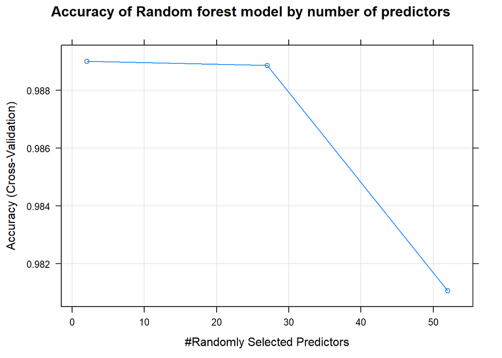

```r
# Train model
trControl <- trainControl(method = "cv", number = 5)
modFit_rf <- train(classe ~ ., data = trainingData_train, method = "rf", trControl = trControl, verboseIter=FALSE)

# Plot model
plot(modFit_rf,main="Accuracy of Random forest model by number of predictors")
```

Then we apply the random forest model on test data in order to evaluate the performamance on new data using the ‘accuracy’ index.

```r
pred_rf <- predict(modFit_rf, newdata = trainingData_test)
cm_rf <- confusionMatrix(pred_rf, trainingData_test$classe)

# Display confusion matrix
cm_rf$table
```

```
##           Reference
## Prediction    A    B    C    D    E
##          A 1671    2    0    0    0
##          B    3 1135    8    0    0
##          C    0    2 1015   13    2
##          D    0    0    3  951    3
##          E    0    0    0    0 1077
```

```r
# Display accuracy index
cm_rf$overall['Accuracy']
```

```
##  Accuracy
## 0.9938828
```

```r
# Diaplay values about the variable 'Classe'
modFit_rf$finalModel$classes
```

```
## [1] "A" "B" "C" "D" "E"
```

```r
# Display the most important variable
varImp(modFit_rf)
```

```
## rf variable importance
##
##   only 20 most important variables shown (out of 52)
##
##                   Overall
## roll_belt          100.00
## yaw_belt            86.64
## magnet_dumbbell_z   77.62
## magnet_dumbbell_y   71.18
## pitch_belt          66.18
## pitch_forearm       62.75
## magnet_dumbbell_x   56.70
## roll_forearm        52.63
## magnet_belt_z       48.07
## accel_dumbbell_y    47.28
## accel_belt_z        46.16
## roll_dumbbell       46.11
## magnet_belt_y       46.10
## accel_dumbbell_z    40.88
## roll_arm            37.89
## gyros_belt_z        34.18
## accel_forearm_x     33.88
## accel_dumbbell_x    32.09
## gyros_dumbbell_y    30.59
## magnet_arm_y        29.84
```

Notes about this second model:

- the **accuracy** index is clearly better than the first model (above **99%**). So the **out of sample error rate** is about **0,0062**, very good;
- the accuracy index is substantially stable up to about 27 predictors; after that, the accuracy rapidly decreases;

Let’s try with the last method.

### Gradient Boosting

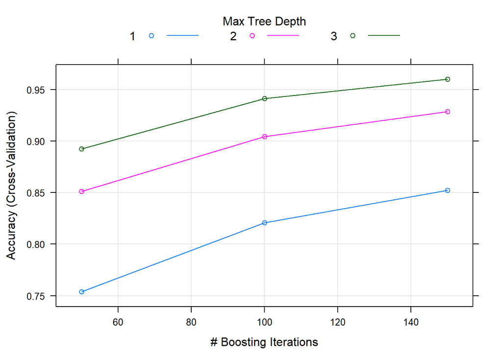

```r
# Train model
trControl <- trainControl(method = "cv", number = 5)
modFit_gbm <- train(classe ~ ., data = trainingData_train, method = "gbm", trControl = trControl, verbose = FALSE)

# Plot model
plot(modFit_gbm)
```

Then we apply the gradient boosting model on test data in order to evaluate the performance on new data using the ‘accuracy’ index.

```r
pred_gbm <- predict(modFit_gbm, newdata = trainingData_test)
cm_gbm <- confusionMatrix(pred_gbm, trainingData_test$classe)

# Display confusion matrix
cm_gbm$table
```

```
##           Reference
## Prediction    A    B    C    D    E
##          A 1643   30    0    1    2
##          B   22 1079   29    2   14
##          C    6   29  982   26    9
##          D    2    1   14  933   15
##          E    1    0    1    2 1042
```

```r
# Display accuracy index
cm_gbm$overall['Accuracy']
```

```
##  Accuracy
## 0.9649958
```

```r
# Diaplay values about the variable 'Class'
modFit_gbm$finalModel$classes
```

```
## [1] "A" "B" "C" "D" "E"
```

Here we have an **accuracy** index about **0.9649**. So, the **out of sample error rate** is about **0,0351** (very good). At last, the best model is clearly the random forests model. So, we use it in order to predict the value about the given test set.

```r
finalPrediction <- predict(modFit_rf, testingData)
finalPrediction
```

```
##  [1] B A B A A E D B A A B C B A E E A B B B
## Levels: A B C D E
```